# Sampling Procedures

Peter Omasta

5/3/2020

## **BEST PRACTICE SURVEYS**

### 1)Target population

The target population for this survey would be the coffee bean farmers. For example in Ethiopia there are over 4 million smallholder farms, this survey would target a small sample population of those farmers in a given region. The sample population would be around 40,000 for the country of Ethiopia ( 1 in 100).

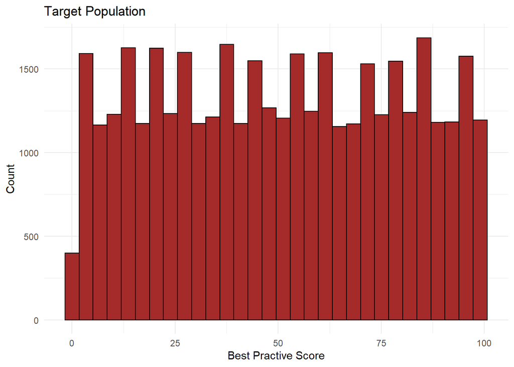

```r
## 2) Target Population Code
set.seed(42)
#draw a sample population with a range of scores from 1:100
population <- declare_population(
  farms = add_level(N=40000,
                    score = sample(1:100, N, replace = TRUE),
                    dist = draw_binary(N=N, prob = 0.6))
)

#create the population data frame
farm_pop <- population()

#visually graph it
farm_popgraph <- ggplot(farm_pop, aes(x=score)) +
  geom_histogram(color="black", fill="brown") +
  labs( y = "Count",
        x = "Best Practive Score",
        title = "Target Population") +
  theme_minimal()

farm_popgraph
```

### 2) Drawing a Sample Code

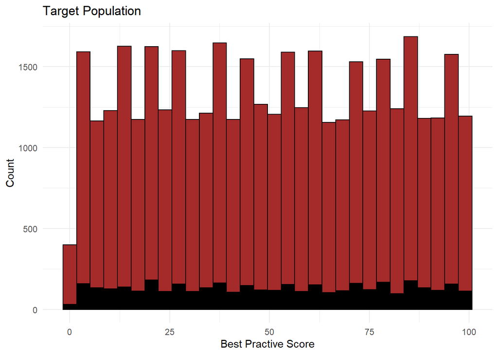

```r
## 2) Drawing a Sample Code
#drawing a sample
e_sam <- sample(1:40000,4000)

#plotting the sample
sample_plot <- ggplot(farm_pop, aes(x=score)) +
  geom_histogram(color="black", fill="brown") +
  geom_histogram(data=farm_pop[e_sam,], fill = "black") +
   labs( y = "Count",
        x = "Best Practive Score",
        title = "Target Population") +
  theme_minimal()

sample_plot
```

### 3) Challenges in drawing a representative sample

These farmers in a region like Ethiopia are going to be difficult to reach via a survey. There is unlikely to be a strong utility infrastructure for mailing a survey to these farmers. In a region of over 4 million farmers, a survey response of 40,000 (which would be 1 in 100) would be an ambitious target. But it would be reasonable to reach that target given these farmers do interact with local co-ops, distributers, and possibly local trade organizations. Sending the surveys to these entities would be more likely. Farmers closer to urban centers may have more access to these entitities than remote farmers thus we will say that farmers closer to an urban center are more likely to respond to the survey (80%) than those farther away (40%).

### 4) Declaration of Reporting Probabilities

```r
## 4) Declaration of Reporting Probabilities
#code for reporting probability based upon distance
reporting_prob <- declare_assignment(
  blocks = dist,
  assignment_variable = "Respond",
  block_prob = c(0.4,0.8))

#create data frame for reporting sample
pop <- reporting_prob(farm_pop) %>%
  select(farms:Respond)
```

### 6) Declaration of Sampling Procedure

```r
## 6) Declaration of Sampling Procedure

sampling <- declare_sampling(n=4000)

farm_estimate <- declare_estimands(mean(score),
                                   label = "Mean Score")

farm_answer <- declare_estimator(dist ~ 1,
                            subset = (Respond == 1),
                            model = lm_robust,
                            label = "est.")

farm_design <- population + reporting_prob + sampling + farm_estimate + farm_answer
summary_design <- diagnose_design(farm_design)

summary_design$diagnosands_df[,c(5,11,13,15)] %>%
  kable()
```

| bias | coverage | mean_estimate | sd_estimate |
| --- | --- | --- | --- |
| -49.76915 | 0 | 0.7502247 | 0.0084178 |

Summary: This data will allow for examining how distance may play a role in survey response for the best practice methods. It will allow for examining how best practices may skew based on the response of the farms and how far they are away from a major city.

## **Climate Smart Water Programs**

Introduction: The goal of this measure (measure 5) is to determine the amount of knowledge gained on climate smart and water management best practices by each farmer that attended GAP and Rehabilitation training courses.

## 2) Declare population:

```r
# 2
set.seed(300)
population <- declare_population(
farmers = add_level(N=150000,
                    knowledge = rnorm(N, mean = 50, sd = 10),
                    learned = ifelse(knowledge > median(knowledge), 1, 0)))


pop <- population()
```

## 3) Challenges of drawing representative sample:

The survey is administered at the end of the training courses. This creates a bias as farmers who started but did not complete the course do not take the survey. We assume that farmers that dropped out of the training courses did so because they were not achieving the learning outcomes laid out at the beginning of the training program. Therefore, the measure of knowledge learned by farmers at the training course only includes farmers that completed the entire course and consequently gained more knowledge than those farmers that did not complete the entirety of the courses.

## 4) Declare reporting probabilities:

```r
reporting <- declare_assignment(blocks = learned,
                                assignment_variable = "R",
                                block_prob = c(0.86, 1))
pop <- reporting(pop)


mean(pop$knowledge)
```

```
## [1] 49.95272
```

## 5) Sampling procedure: The survey would be administered to all farmers (139,609) who completed the entirety of the Farm College training courses in East Africa from 2008 to 2016.